# Alcohol Beverage Services (ABS)

# 10. Counts of Sizes / Packs by Department

This section examines the frequency distribution of product sizes and pack configurations across departments. Counts of each unit type are computed to assess assortment breadth and operational complexity within categories. A bubble plot visualization is used to simultaneously display frequency, relative magnitude, and departmental grouping, enabling comparison of how product variety differs across major departments.

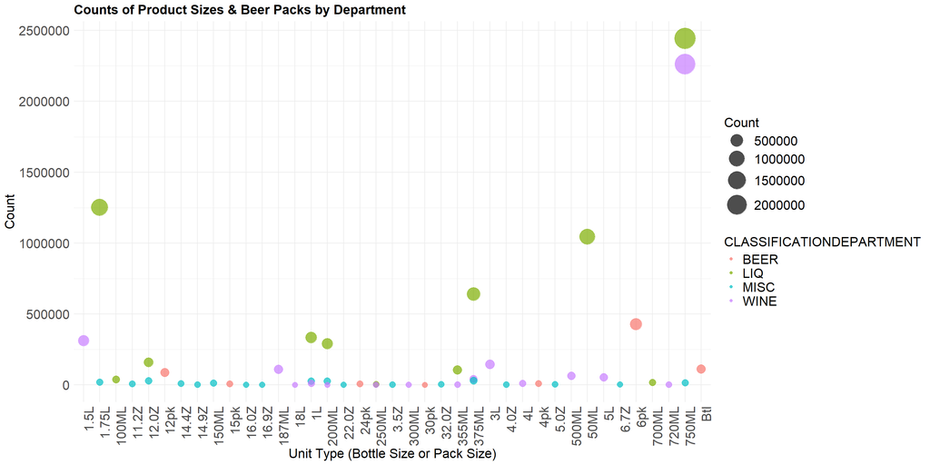

```r
# Frequency of size/pack combinations within departments
size_counts <- transactions %>%
  group_by(CLASSIFICATIONDEPARTMENT, UnitType) %>%
  summarise(Count = n(), .groups = "drop") %>%
  arrange(desc(Count))

# Bubble plot of size/pack frequencies
ggplot(size_counts,
       aes(x = UnitType, y = Count, size = Count, color = CLASSIFICATIONDEPARTMENT)) +
  geom_point(alpha = 0.7) +
  scale_size(range = c(3, 12)) +
  labs(
    title = "Counts of Product Sizes & Beer Packs by Department",
    x     = "Unit Type (Bottle Size or Pack Size)",
    y     = "Count"
  ) +
  theme_minimal() +
  theme(
    axis.text.x  = element_text(angle = 90, hjust = 1, size = 16),   # x-axis labels
    axis.text.y  = element_text(size = 16),                          # y-axis labels
    axis.title.x = element_text(size = 16),                          # x-axis title
    axis.title.y = element_text(size = 16),                          # y-axis title
    plot.title   = element_text(size = 16, face = "bold"),           # plot title
    legend.text  = element_text(size = 16),                          # legend labels
    legend.title = element_text(size = 16)                           # legend title
  )
```

# Interpretation: Product Size and Pack Frequency

The frequency distribution of unit types is highly skewed, with a few size and pack configurations appearing in a large proportion of transaction records and many others occurring rarely. This imbalance indicates that assortment breadth is not evenly utilized and that a substantial portion of SKU variety contributes marginally to observed transaction activity. Such patterns are relevant for evaluating replenishment efficiency and shelf-space allocation.

# 11. Category Mix by Store (Wide Pivot)

Store-level category mix is analyzed by calculating department-specific sales shares for each store. These shares are reshaped into a wide, store-by-department matrix to facilitate comparison across locations and to support downstream modeling. In parallel, sales shares by day type (holiday, weekend, weekday) are computed for each store to capture temporal demand patterns. Together, these features provide a structured representation of each store’s sales composition across both product categories and time dimensions.

```r
# Department-level sales and shares by store
store_dept_sales <- transactions %>%
  filter(!IsRefund) %>%
  group_by(STORENAME, CLASSIFICATIONDEPARTMENT) %>%
  summarise(
    TotalSales = sum(NETAMOUNT, na.rm = TRUE),
    TotalQty   = sum(LINEQTY,   na.rm = TRUE),
    .groups    = "drop"
  )

store_dept_mix <- store_dept_sales %>%
  group_by(STORENAME) %>%
  mutate(
    StoreTotalSales = sum(TotalSales, na.rm = TRUE),
    DeptShare       = TotalSales / StoreTotalSales
  ) %>%
  ungroup()

# Store-by-department share matrix
store_category_mix <- store_dept_mix %>%
  select(STORENAME, CLASSIFICATIONDEPARTMENT, DeptShare) %>%
  pivot_wider(
    names_from  = CLASSIFICATIONDEPARTMENT,
    values_from = DeptShare,
    values_fill = 0,
    names_prefix = "Share_"
  )

store_category_mix
```

```
## # A tibble: 27 × 5
##    STORENAME          Share_BEER Share_LIQ Share_MISC Share_WINE
##    <chr>                   <dbl>     <dbl>      <dbl>      <dbl>
##  1 Aspen Hill             0.0919     0.698    0.00700      0.203
##  2 Burtonsville           0.0725     0.632    0.00763      0.288
##  3 Cabin John             0.0651     0.554    0.0109       0.370
##  4 Clarksburg Village     0.0773     0.618    0.00753      0.297
##  5 Cloverly               0.0570     0.670    0.00749      0.266
##  6 Darnestown             0.0548     0.558    0.00918      0.378
##  7 Downtown Rockville     0.0490     0.663    0.00872      0.279
##  8 Fallsgrove             0.0546     0.637    0.00812      0.300
##  9 Flower                 0.0712     0.670    0.00760      0.251
## 10 Gaithersburg           0.0437     0.765    0.0105       0.181
## # ℹ 17 more rows
```

```r
# Day-type (Holiday / Weekend / Weekday) mix by store
store_daytype_mix <- transactionsFS %>%
  group_by(STORENAME, DayType) %>%
  summarise(DaySales = sum(NETAMOUNT, na.rm = TRUE), .groups = "drop") %>%
  group_by(STORENAME) %>%
  mutate(DayShare = DaySales / sum(DaySales, na.rm = TRUE)) %>%
  ungroup() %>%
  select(STORENAME, DayType, DayShare) %>%
  pivot_wider(
    names_from  = DayType,
    values_from = DayShare,
    values_fill = 0,
    names_prefix = "Share_"
  )

store_daytype_mix %>% count(STORENAME)
```

```
## # A tibble: 27 × 2
##    STORENAME              n
##    <chr>              <int>
##  1 Aspen Hill             1
##  2 Burtonsville           1
##  3 Cabin John             1
##  4 Clarksburg Village     1
##  5 Cloverly               1
##  6 Darnestown             1
##  7 Downtown Rockville     1
##  8 Fallsgrove             1
##  9 Flower                 1
## 10 Gaithersburg           1
## # ℹ 17 more rows
```

```r
store_daytype_mix %>%
  mutate(sum_shares = Share_Holiday + Share_Weekday + Share_Weekend) %>%
  select(STORENAME, sum_shares)
```

```
## # A tibble: 27 × 2
##    STORENAME          sum_shares
##    <chr>                   <dbl>
##  1 Aspen Hill                  1
##  2 Burtonsville                1
##  3 Cabin John                  1
##  4 Clarksburg Village          1
##  5 Cloverly                    1
##  6 Darnestown                  1
##  7 Downtown Rockville          1
##  8 Fallsgrove                  1
##  9 Flower                      1
## 10 Gaithersburg                1
## # ℹ 17 more rows
```

# Interpretation: Store-Level Category and Day-Type Mix

Stores exhibit substantial heterogeneity in both category composition and temporal demand structure. Because department and day-type shares sum to one within each store, differences reflect true trade-offs rather than independent effects. These compositional differences imply that stores operate under distinct demand profiles, justifying their explicit inclusion as predictors in the regression models rather than treating them as background context.

# 12. Daily Sales & FY-Comparison – Calendar Alignment

This section examines daily sales patterns across fiscal years while accounting for calendar effects. Daily total sales are aggregated across all stores and then aligned by weekday within each month to control for differences in calendar structure between years. This weekday-aligned approach allows for more meaningful comparison of intra-month sales patterns by reducing distortions caused by shifting weekends and holidays. Separate visualizations are produced for FY23–24 and FY24–25 to facilitate direct comparison of seasonal and weekday-driven demand patterns.

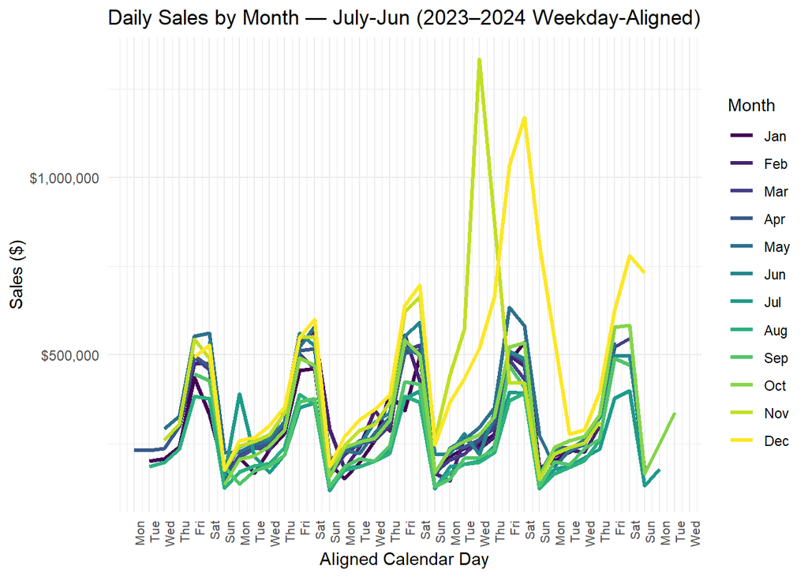

```r
# Aggregate daily sales across all stores
daily_sales_ts <- transactionsFS %>%
  group_by(TRANSDATE) %>%
  summarise(TotalSales = sum(NETAMOUNT, na.rm = TRUE), .groups = "drop") %>%
  mutate(
    Day   = day(TRANSDATE),
    Month = month(TRANSDATE, label = TRUE, abbr = TRUE),
    Year  = year(TRANSDATE)
  )

# Align Y23–24 by weekday within month
y23_24_aligned <- daily_sales_ts %>%
  filter(
    TRANSDATE >= as.Date("2023-07-01"),
    TRANSDATE <= as.Date("2024-06-30")
  ) %>%
  mutate(
    FirstOfMonth  = floor_date(TRANSDATE, "month"),
    WeekdayOffset = wday(FirstOfMonth, week_start = 1) - 1,
    DayAligned    = day(TRANSDATE) + WeekdayOffset
  )

# Align Y24–25 by weekday within month
y24_25_aligned <- daily_sales_ts %>%
  filter(
    TRANSDATE >= as.Date("2024-07-01"),
    TRANSDATE <= as.Date("2025-06-30")
  ) %>%
  mutate(
    FirstOfMonth  = floor_date(TRANSDATE, "month"),
    WeekdayOffset = wday(FirstOfMonth, week_start = 1) - 1,
    DayAligned    = day(TRANSDATE) + WeekdayOffset
  )

# Label for aligned weekdays
weekday_labels <- rep(c("Mon","Tue","Wed","Thu","Fri","Sat","Sun"), length.out = 40)

# Weekday-aligned daily sales – Y23–24
ggplot(y23_24_aligned, aes(x = DayAligned, y = TotalSales, color = Month, group = Month)) +
  geom_line(linewidth = 1.1) +
  labs(
    title = "Daily Sales by Month — July-Jun (2023–2024 Weekday-Aligned)",
    x     = "Aligned Calendar Day",
    y     = "Sales ($)"
  ) +
  scale_x_continuous(
    breaks = seq(1, 40, by = 1),
    labels = weekday_labels
  ) +
  scale_y_continuous(labels = dollar) +
  theme_minimal() +
  theme(axis.text.x = element_text(angle = 90, hjust = 1, size = 8))
```

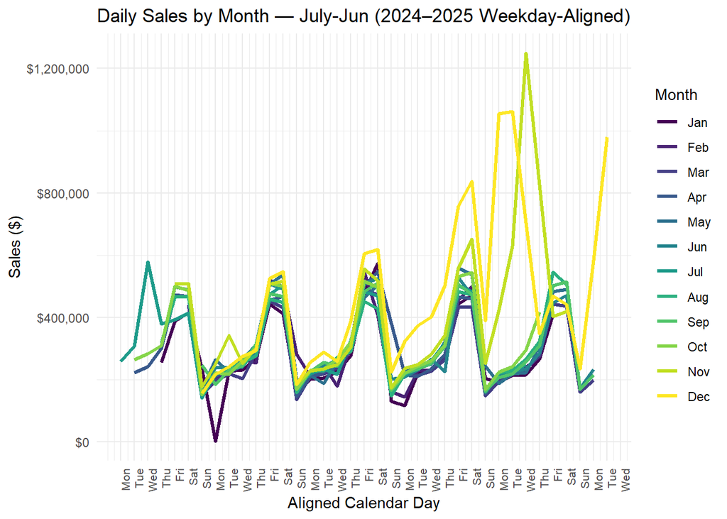

```r
# Weekday-aligned daily sales – Y24–25
ggplot(y24_25_aligned, aes(x = DayAligned, y = TotalSales, color = Month, group = Month)) +
  geom_line(linewidth = 1.1) +
  labs(
    title = "Daily Sales by Month — July-Jun (2024–2025 Weekday-Aligned)",
    x     = "Aligned Calendar Day",
    y     = "Sales ($)"
  ) +
  scale_x_continuous(
    breaks = seq(1, 40, by = 1),
    labels = weekday_labels
  ) +
  scale_y_continuous(labels = dollar) +
  theme_minimal() +
  theme(axis.text.x = element_text(angle = 90, hjust = 1, size = 8))
```

# Interpretation: Weekday-Aligned Daily Sales Patterns

Weekday alignment reveals recurring intra-month sales patterns that are consistent across years, with visible peaks and troughs tied to the weekly sales cycle. While overall sales levels differ between FY23–24 and FY24–25, the similarity in shape across months suggests that short-term demand is strongly influenced by calendar structure rather than random variation. This supports the use of calendar-adjusted comparisons in subsequent performance analysis.

# 13. Monthly Sales Comparison: July-Jun (23–24 vs 24–25)

To evaluate broader year-over-year trends, monthly total sales are aggregated for each year using a consistent July–June reporting window. Monthly sales trajectories for FY23–24 and FY24–25 are plotted together to assess differences in overall growth, seasonality, and relative performance across corresponding months. This comparison provides a high-level view of year performance that complements the more granular daily analysis.

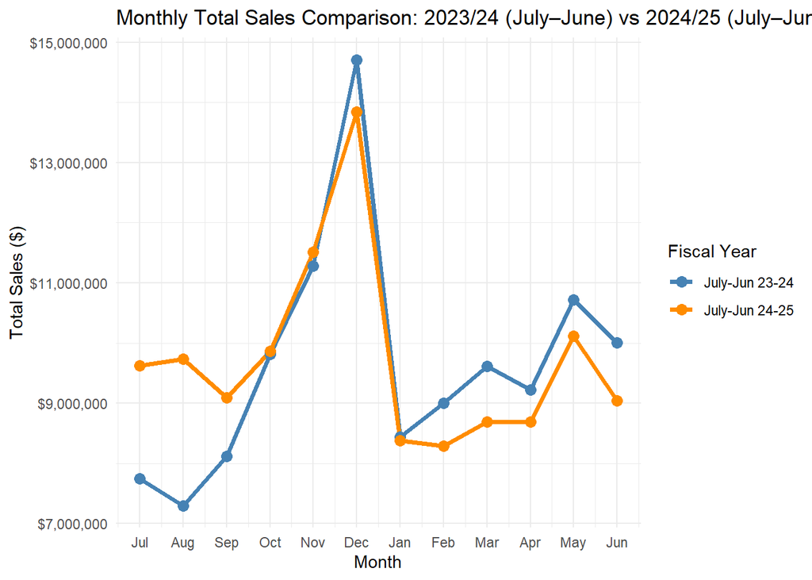

```r
# Year–month string for monthly aggregation
transactionsFS <- transactionsFS %>%
  mutate(YearMonth = format(TRANSDATE, "%Y-%m"))

# Monthly total sales – July-Jun 23–24
y23_24_monthlyFS <- transactionsFS %>%
  filter(TRANSDATE >= "2023-07-01" & TRANSDATE <= "2024-06-30") %>%
  group_by(YearMonth) %>%
  summarise(TotalSales = sum(NETAMOUNT), .groups = "drop") %>%
  arrange(YearMonth) %>%
  mutate(FYear = "July-Jun 23-24", MonthIndex = row_number())

# Monthly total sales – July-Jun 24–25
y24_25_monthlyFS <- transactionsFS %>%
  filter(TRANSDATE >= "2024-07-01" & TRANSDATE <= "2025-06-30") %>%
  group_by(YearMonth) %>%
  summarise(TotalSales = sum(NETAMOUNT), .groups = "drop") %>%
  arrange(YearMonth) %>%
  mutate(FYear = "July-Jun 24-25", MonthIndex = row_number())

# Combine fiscal years for comparison
combined_monthlyFS <- rbind(y23_24_monthlyFS, y24_25_monthlyFS)

ggplot(combined_monthlyFS, aes(x = MonthIndex, y = TotalSales, color = FYear, group = FYear)) +
  geom_line(linewidth = 1.3) +
  geom_point(size = 3) +
  scale_x_continuous(
    breaks = 1:12,
    labels = c("Jul","Aug","Sep","Oct","Nov","Dec","Jan","Feb","Mar","Apr","May","Jun")
  ) +
  scale_color_manual(values = c("July-Jun 23-24"="steelblue", "July-Jun 24-25"="darkorange")) +
  labs(
    title = "Monthly Total Sales Comparison: 2023/24 (July–June) vs 2024/25 (July–June)",
    x     = "Month",
    y     = "Total Sales ($)",
    color = "Fiscal Year"
  ) +
  scale_y_continuous(labels = dollar) +
  theme_minimal()
```

#Interpretation: Fiscal-Year Monthly Sales Comparison

Monthly sales exhibit clear seasonality across both years, with comparable peaks and declines occurring in similar months. Differences in the relative height of the lines indicate changes in overall sales levels between years, while the shared seasonal pattern suggests stable demand timing. This comparison provides context for evaluating whether store-level performance changes reflect broader system-wide trends or localized effects.